# Single-copy genes missing and present from Rumex xyy male haplotype assemblies and Rumex salicifolius

### Setup and data cleaning

Goal: obtain a list of 1-1 syntenic orthologs that are present in hap1 and sal, but not hap2 - as well as the opposite case. Particularly interested in the sex chromosomes.

```r
#library(renv)
library(tidyverse)
library(vroom)
#library(GENESPACE)
#library(googlesheets4)
#setwd("~/Dropbox/rumex_pangenome_annotation")
```

#### raw files

Loading in wide format from query_pangenes() for each possible reference and bed files.

```r
# excluded non representative array members and non-syntenic othogroups (see genespace script)
hap1_raw<-data.table::fread("pg_hap1_wide_synonly.txt")
hap2_raw<-data.table::fread("pg_hap2_wide_synonly.txt")
sal_raw<-data.table::fread("pg_sal_wide_synonly.txt")
hap1_nonsyn<-data.table::fread("pg_hap1_wide.txt")
```

#### Filtering pangenome IDs w NS orths

Eliminating pangenome ID groups w non-syn orthogroup members. This is to get a more conservative set of “gene loss” candidates. NS orths are still of interest will be analyzed separately.

```r
# NSorths in the hap1_nonsyn file are annotated with a *
# creating a list with grepl - any entry with a *
nsorths<-hap1_nonsyn %>% filter_all(any_vars(grepl("\\*",.)))
# filtering out any pgIDs in that set
onlysyn<-hap1_raw %>% filter(!(pgID%in%nsorths$pgID)) # 31289 genes remain
# same with salicifolius
#onlysyn_sal<-sal_raw %>% filter(!(pgID%in%nsorths$pgID)) # 29906
```

### Gene loss on Y

Identify genes that are shared by salicifolius and hap1, but not hap2. Adding position of PARS and correct denominator for calculating proportions.

#### defining lost genes

```r
hasanortho<-onlysyn %>%
  filter((hap1!=""|hap2!="")&salicifolius!="")

notlost<-onlysyn %>% filter((hap1!="" & hap2!="" & salicifolius!=""))
#write_delim(hasanortho,"denomgenelist.txt",delim="\t")
#write_delim(hasanortho_justsal,"denomgenelist_salorth.txt",delim="\t")
#write_csv(salorths, "denomgenelist_salorths.csv")
hap1_yloss<-onlysyn %>% filter(hap1!="" & hap2=="" & salicifolius!="")
```

#### functions to label and summarise data in sex-linked regions

Need to tabulate gene loss between PARs, oldx, newx, etc.

```r
#######################################
###--- functions----
#######################################
# major change from prev version: use chr instead of interpChr (for more accurate placement of SLRs)
slr_rename_h1<-function(x){mutate(x,region=if_else(chr =="X" & end<=71000000,"PAR1",
                        if_else(chr =="X" & (end>71000000 & end<=261000000),"OldX",
                        if_else(chr=="X" & (end>261000000 & end<=367000000),"NewX",
                        if_else(chr=="X" & end>367000000,"PAR2",
                        if_else(chr=="A1","A1",
                        if_else(chr=="A2","A2",
                        if_else(chr=="A4","A4",NA))))))))}
yloss_pars<-slr_rename_h1(hap1_yloss)
# summarize numbers by region
summarisebyregion<-function(x,y){ x %>% tibble() %>%
  group_by(region) %>% summarise({{y}}:=n()) %>%
  filter(!is.na(region))}
summary_yloss_pars<-summarisebyregion(yloss_pars,n_yloss)

total_pangenes<-slr_rename_h1(hasanortho)
summary_total_pangenes<-summarisebyregion(total_pangenes,n_total)
```

### BLAST gene loss confirmation

#### obtain list of y loss candidates to blast confirm

These genes will be BLASTed to the whole hap2 genome.

```r
genelisth1<-hap1_yloss %>% dplyr::select(hap1)
genelisth1_chr<-hap1_yloss %>% dplyr::select(hap1,interpChr)
#write.table(genelisth1,"genelisthap1.txt",quote=FALSE,sep="\t",row.names=F)
```

#### BLAST script

Ran this in server where BLAST is installed.

```bash
cat blast_genome.sh
```

```
## #!/bin/bash
##
## ## redoing blast with the whoel genome not just the transcriptome
## #fasta="NChap1.out.fasta"
## #genelist="genelisthap1.out.txt"
## #while read i; do
## #    samtools faidx $fasta $i >> hap1_sequences.fa
## #done < $genelist
##
## echo "creating hap2 genome db"
##
## makeblastdb -in /ohta2/Rumex/Dovetail_xyy_pacbio-male/final_scaffolded_assemblies/NChap2_final.fa \
##  -input_type fasta -dbtype nucl -out hap2genome
##
## wait
##
## echo "blasting hap1 sequences to hap2 geno"
##
## blastn -db hap2genome -query hap1_sequences.fa \
##  -max_hsps 1 \
##  -outfmt "6 qseqid sseqid pident length mismatch gapopen qstart qend qlen sstart send slen evalue bitscore score" \
##  -out blast_h2genome.tsv
```

#### futher analysis of blast output in R

```r
blastout<-read_tsv("blast_h2genome.tsv",
                    col_names = c("qseqid", "sseqid", "pident", "length",
                                  "mismatch", "gapopen", "qstart", "qend",
                                  "qlen", "sstart", "send", "slen", "evalue",
                                  "bitscore", "score"))

blast_pos<-full_join(blastout,hap2_raw,by=c("qseqid"="hap1"))  %>% add_count(qseqid)
### which genes, out of any, are no hits in hap2 genome
hits<-blastout %>% dplyr::select(qseqid) %>% distinct()
nohit<- anti_join(genelisth1,hits, by = c("hap1"="qseqid"))
tophit_geneonly<- blastout %>% group_by(qseqid) %>%
  mutate(the_rank  = rank(-pident, ties.method = "random")) %>%
  filter(the_rank == 1) %>%
  dplyr::select(-the_rank) %>% mutate(alignedpropn = length/qlen)
tophit_geneonly
```

```
## # A tibble: 731 × 16
## # Groups:   qseqid [731]
##    qseqid sseqid pident length mismatch gapopen qstart  qend  qlen sstart   send
##    <chr>  <chr>   <dbl>  <dbl>    <dbl>   <dbl>  <dbl> <dbl> <dbl>  <dbl>  <dbl>
##  1 NChap… Y1       99.7    385        1       0      1   385   534 3.43e8 3.43e8
##  2 NChap… A1      100       28        0       0   1042  1069  1095 1.26e8 1.26e8
##  3 NChap… Y1       99.8    426        1       0    172   597   597 3.43e8 3.43e8
##  4 NChap… Y2      100       66        0       0   1462  1527  1527 2.10e7 2.10e7
##  5 NChap… Y1      100      197        0       0    625   821  1026 3.43e8 3.43e8
##  6 NChap… Y1       98.7    393        5       0    852  1244  1337 3.41e8 3.41e8
##  7 NChap… Y1       99.8    566        1       0    767  1332  1520 3.41e8 3.41e8
##  8 NChap… Y1      100      547        0       0      1   547  1400 3.41e8 3.41e8
##  9 NChap… Y1       99.5    627        3       0      1   627  1513 3.41e8 3.41e8
## 10 NChap… Y1      100     1122        0       0   2297  3418  4355 3.41e8 3.41e8
## # ℹ 721 more rows
## # ℹ 5 more variables: slen <dbl>, evalue <dbl>, bitscore <dbl>, score <dbl>,
## #   alignedpropn <dbl>
```

#### exclude paralogs from blast top hit list

```r
tophit_samechr<- tophit_geneonly %>%
  left_join(genelisth1_chr,by=c("qseqid"="hap1")) %>%
  mutate(matchchr=if_else(interpChr == "X", "Y",
                           if_else(interpChr == "A1","A1",
                           if_else(interpChr == "A2","A2",
                           if_else(interpChr == "A4","A4",NA))))) %>%
  filter(str_detect(sseqid,matchchr))
tophit_partial<- tophit_samechr %>% filter(alignedpropn <= 0.5)
tophit_notloss<-tophit_samechr %>% filter(alignedpropn > 0.5)

updated_genelist <- genelisth1 %>% filter(!hap1%in%tophit_notloss$qseqid)
#write.table(updated_genelist,"genelisthap1_blast.txt",quote=FALSE,sep="\t",row.names=F)
```

#### obtain list of lost genes per region

```r
yloss_blast<- slr_rename_h1((hap1_yloss %>% filter(!hap1%in%tophit_notloss$qseqid)))
summary_yloss_blast <-summarisebyregion(yloss_blast,n_blastconfirmedloss)

yloss_partial <- slr_rename_h1((filter(hap1_yloss,hap1%in%tophit_partial$qseqid)))
summary_yloss_partial <-summarisebyregion(yloss_partial,n_partialloss)
#write.csv(yloss_partial,"yloss_partial_Sept2023.csv")

complete_yloss<- slr_rename_h1((hap1_yloss %>% filter(!hap1%in%tophit_notloss$qseqid))) %>% filter(!hap1%in%tophit_partial$qseqid)
#write.csv(complete_yloss,"complete_yloss_Sept2023.csv")

### adding genes not lost frmo blast result to list of genes with all 3 orthos ("no loss")
retained_blast<-slr_rename_h1((hap1_yloss %>% filter(hap1%in%tophit_notloss$qseqid)))
notlost<-slr_rename_h1(notlost)
retained_y<-rbind(notlost, retained_blast) %>% distinct()
#write.csv(retained_y,"retained_genes_Sept2023.csv")
# above file is just genes that failed blast loss confirmation1!!
# needs to be aded to other total.

#retained_on_y<-slr_rename_h1((hasanortho


mylist<-list(summary_total_pangenes,summary_yloss_pars,
             summary_yloss_blast,summary_yloss_partial)

combinedsummary<-mylist %>% purrr::reduce(left_join,by="region")
propnsummary<-combinedsummary %>%
  mutate(propn_yloss=n_yloss/n_total,
         propn_blastconfirmedloss=n_blastconfirmedloss/n_total,
         propn_partiallosstot=n_partialloss/n_total,
         propn_partiallossbl=n_partialloss/n_blastconfirmedloss) %>%
  mutate(region = factor(region, levels=c("A1","A2","A4","PAR1","OldX","NewX","PAR2")))

print(propnsummary)
```

```
## # A tibble: 7 × 9
##   region n_total n_yloss n_blastconfirmedloss n_partialloss propn_yloss
##   <fct>    <int>   <int>                <int>         <int>       <dbl>
## 1 A1        2786     145                   74            73      0.0520
## 2 A2        2833     170                   93            82      0.0600
## 3 A4        1535     102                   53            49      0.0664
## 4 NewX       252      10                    7             7      0.0397
## 5 OldX       745     275                  252            94      0.369
## 6 PAR1       793      61                   30            26      0.0769
## 7 PAR2      1295      83                   55            53      0.0641
## # ℹ 3 more variables: propn_blastconfirmedloss <dbl>,
## #   propn_partiallosstot <dbl>, propn_partiallossbl <dbl>
```

### control/opposite - hap1 gene loss

is there X loss?

```r
hap2_nonsyn<-data.table::fread("pg_hap2_wide.txt")
nsorths2<-hap2_nonsyn %>% filter_all(any_vars(grepl("\\*",.)))

onlysyn2<-hap2_nonsyn %>% filter(!(pgID%in%nsorths2$pgID)) # 30505 genes remain?
#
hasanortho2<-onlysyn2 %>%
   filter(((hap1!=""|hap2!="")&salicifolius!=""))
hap2_xloss<-hasanortho2 %>% filter(hap1=="" & hap2!="" & salicifolius!="")

slr_rename_h2<- function(x){mutate(x,
   region=if_else(chr=="Y1" & end<=64000000,"NewY1",
          if_else(chr =="Y1" & (end>64000000 & end<=272000000),"OldY1",
          if_else(chr =="Y1" & (end > 272000000 & end <= 344000000),"PAR1",
     if_else(chr=="Y2" & end<=121000000,"PAR2",
     if_else(chr=="Y2"& (end>121000000 & end<=159000000),"NewY2",
     if_else(chr=="Y2" & end>159000000, "OldY2",
     if_else(chr=="A1","A1",
     if_else(chr=="A2","A2",
     if_else(chr=="A4","A4",NA))))))))))}

pars_xloss<-slr_rename_h2(hap2_xloss)

summary_xloss_pars<-summarisebyregion(pars_xloss,n_xloss)

total_pangenes2<-slr_rename_h2(hasanortho2)

summary_total_pangenes2<-summarisebyregion(total_pangenes2,n_total)

chrpropnPAR_xloss<-full_join(summary_total_pangenes2,summary_xloss_pars,by="region") %>%
  mutate(., propn=n_xloss/n_total)  %>%
  mutate(region =
    factor(region,levels=c("A1","A2","A4","PAR1","OldY1","NewY2","OldY2","NewY1","PAR2")))

#write_delim(chrpropnPAR_xloss,"summary_xloss.txt")
print(chrpropnPAR_xloss)
```

```
## # A tibble: 9 × 4
##   region n_total n_xloss   propn
##   <fct>    <int>   <int>   <dbl>
## 1 A1        2702      67 0.0248
## 2 A2        2714      67 0.0247
## 3 A4        1451      30 0.0207
## 4 NewY1      145       1 0.00690
## 5 NewY2       96       2 0.0208
## 6 OldY1      206       3 0.0146
## 7 OldY2      280       7 0.025
## 8 PAR1       755      20 0.0265
## 9 PAR2      1236      27 0.0218
```

## plotting y and x loss

### bar plots

```r
## create data frame
plotdata_yloss<- propnsummary %>%
  mutate(n_retained = n_total - n_blastconfirmedloss) %>%
  mutate(propncompletelylost
         = propn_blastconfirmedloss - propn_partiallosstot) %>%
  select(.,region,propncompletelylost,
         propn_partiallosstot,propn_blastconfirmedloss) %>%
  pivot_longer(cols = 2:4)

plotdata_xloss <- chrpropnPAR_xloss %>%
  dplyr::rename(propn_xloss=propn) %>%
  select(.,region,propn_xloss) %>%
  pivot_longer(cols = 2)

plotdata<-dplyr::bind_rows(plotdata_yloss,plotdata_xloss)

plotdata2 <-plotdata %>%
  mutate(region = if_else(str_detect(region,"^A."), "Autosomes",region))%>%
  mutate(region = if_else(str_detect(region,"PAR*"), "Pseudoautosomal region",region)) %>%
  mutate(region = if_else(str_detect(region,"New*"), "New sex-linked region",region)) %>%
  mutate(region = if_else(str_detect(region,"Old*"), "Old sex-linked region",region)) %>%
  mutate(.,region = factor(region, levels=c("Old sex-linked region",
                                            "New sex-linked region","Autosomes","Pseudoautosomal region")))

bothlossplot<-ggplot(filter(plotdata2,name == "propn_blastconfirmedloss"|
                name =="propn_xloss"),
       aes(x = name,y = value,fill=region)) +geom_col(position="dodge") +
  cowplot::theme_cowplot() +
  scale_fill_brewer(palette = "Dark2") +
  scale_x_discrete(labels=c('Paternal haplotype\n', 'Maternal haplotype\n')) +
  ylab("Proportion of\n genes lost") +
  xlab("Comparison between haplotypes") +
  theme(legend.position = "none") +
  ylim(0,0.4)
```

```r
plotdata3 <-plotdata_yloss %>%
  mutate(region = if_else(str_detect(region,"^A."), "Autosomes",region))%>%
  mutate(region = if_else(str_detect(region,"PAR*"), "Pseudoautosomal region",region)) %>%
  mutate(region = if_else(str_detect(region,"New*"), "New sex-linked region",region)) %>%
  mutate(region = if_else(str_detect(region,"Old*"), "Old sex-linked region",region)) %>%
  mutate(.,region = factor(region, levels=c("Old sex-linked region",
                                            "New sex-linked region","Autosomes","Pseudoautosomal region")))


ylossplot<-ggplot(filter(plotdata3,name == "propncompletelylost"|
                name =="propn_partiallosstot"),
       aes(x = name,y = value,fill=region)) +geom_col(position="dodge") +
  cowplot::theme_cowplot() +
  scale_fill_brewer(palette = "Dark2") +
  scale_x_discrete(labels=c('partial loss\n', 'complete loss\n')) +
  ylab("Proportion of genes lost") +
  xlab("Partial vs. complete gene loss\n in paternal haplotype") +
  theme(legend.position = "none") +
  ylim(0,0.4)



library(cowplot)
mylegend<-cowplot::get_legend(ylossplot+theme(legend.position = 'bottom',
                    legend.justification="centre",legend.title=element_blank()))

bottom_row <- plot_grid(mylegend)
upper_row <- plot_grid(bothlossplot,ylossplot+theme(axis.title.y=element_blank(),
        axis.text.y=element_blank(),
        axis.ticks.y=element_blank(),
        axis.line.y=element_blank()),ncol=2,align="h",axis="tb")
# bothlossplot<-cowplot::plot_grid(upper_row,
#          bottom_row,
#         labels = c('',''),
#         ncol = 1, rel_heights = c(5,1))
# bothlossplot
#ggsave("genelossmulti_july12.pdf",dpi = 300, width = 10, height = 4, units = "in")
#ggsave("genelossmulti_july12.jpg",dpi = 300, width = 10, height = 4, units = "in")
```

### gene loss in windows on X

What do I need? - list of missing genes - list of missing genes along X - list of all genes along X - calculation of # of genes in # gene windows that are missing - sliding win?

```r
head(hasanortho)
```

```
##    pgID interpChr interpOrd    og               repGene genome chr  start
## 1:    3         X         4 14439 NChap1_final_00000004   hap1   X 403065
## 2:    4         X         5 14570 NChap1_final_00000005   hap1   X 471220
## 3:    5         X         6 17887 NChap1_final_00000006   hap1   X 478724
## 4:   10         X         8 14492 NChap1_final_00000008   hap1   X 484777
## 5:   15         X        10 14600 NChap1_final_00000010   hap1   X 509516
## 6:   22         X        13 14914 NChap1_final_00000013   hap1   X 523470
##       end                  hap1            salicifolius                  hap2
## 1: 420694 NChap1_final_00000004 R_salicifolius_00022220 NChap2_final_00025377
## 2: 478043 NChap1_final_00000005 R_salicifolius_00022221 NChap2_final_00025375
## 3: 480411 NChap1_final_00000006 R_salicifolius_00022222
## 4: 486768 NChap1_final_00000008 R_salicifolius_00022226 NChap2_final_00025373
## 5: 515085 NChap1_final_00000010 R_salicifolius_00022230 NChap2_final_00025371
## 6: 528010 NChap1_final_00000013 R_salicifolius_00022237 NChap2_final_00025370
```

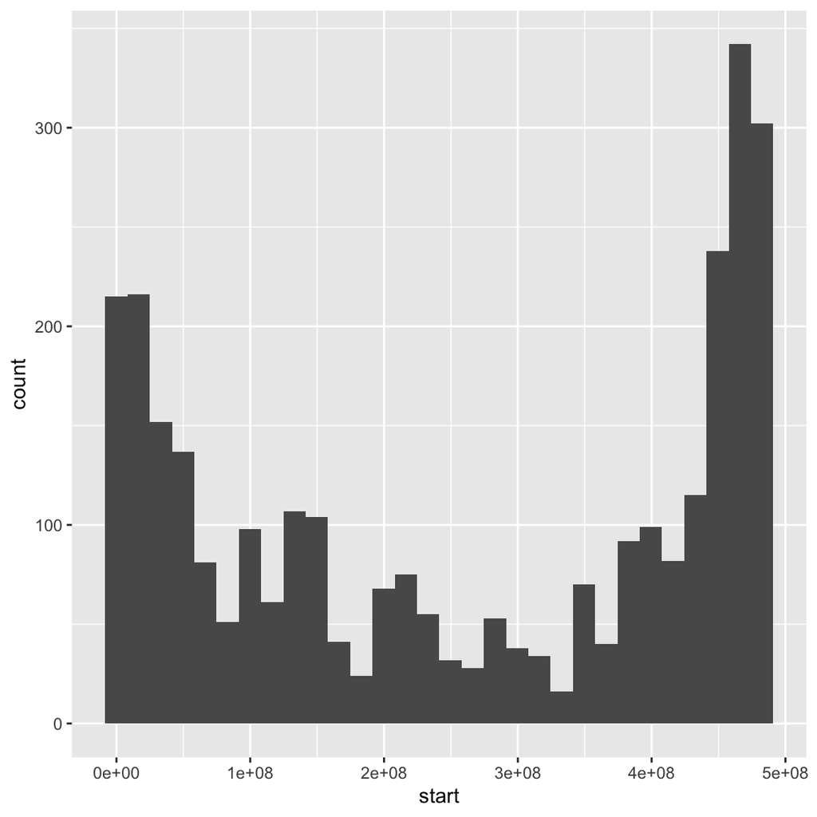

```r
xtotal<-filter(hasanortho,chr == "X") %>%  filter(!grepl("\\|",hap1))
ggplot(data = xtotal, aes(start)) + geom_histogram()
```

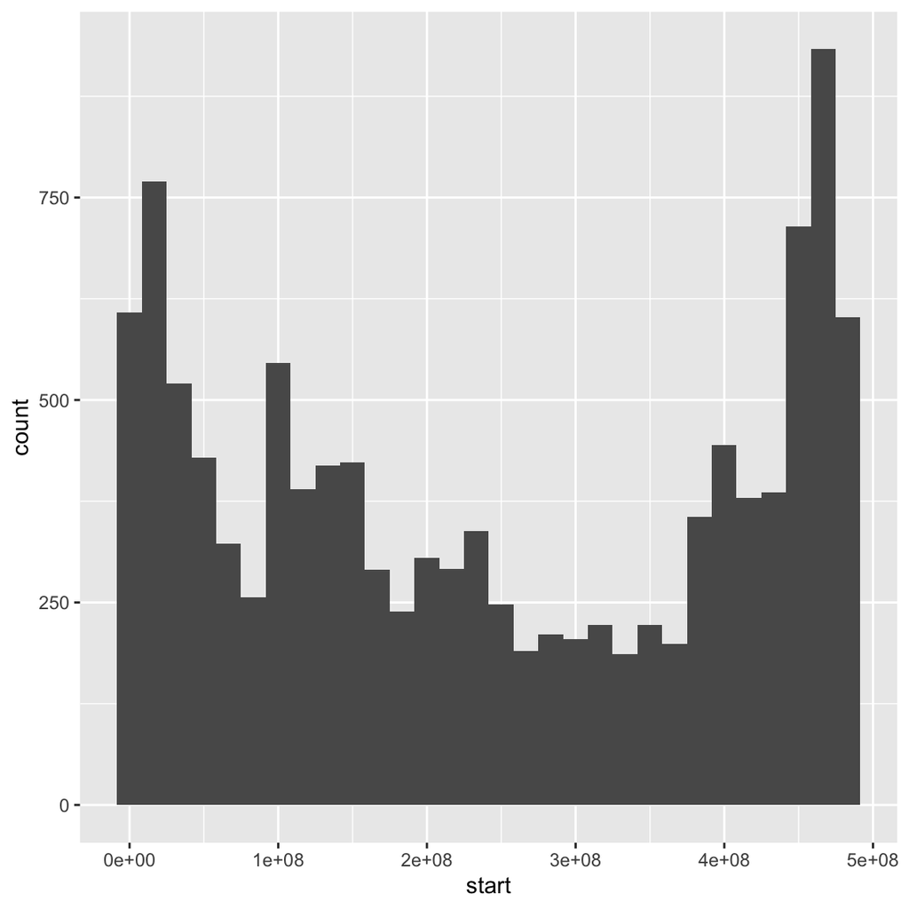

```r
#dim(xtotal) # 3085
## compare to bed?
hap1bed<-read.delim("hap1.bed",col.names =c("chr","start","end","hap1"))
xtotalbed<-filter(hap1bed,chr =="X")
#dim(xtotalbed) # lol way more genes. 11644
ggplot(data = xtotalbed,aes(start)) +geom_histogram()
```

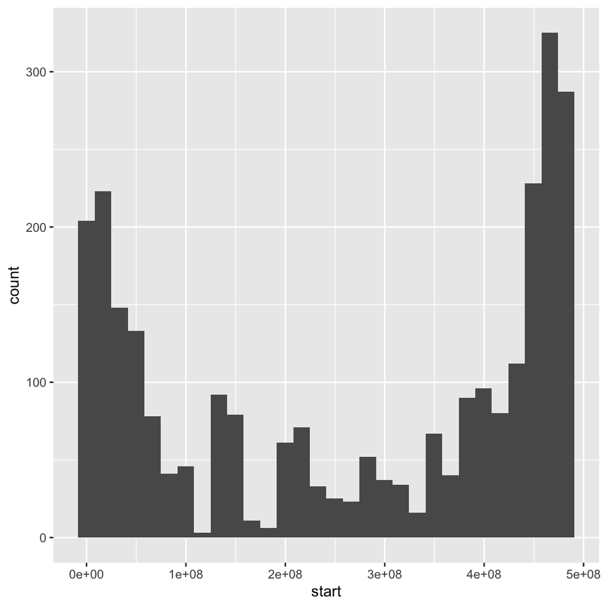

```r
## plot retained genes distribution
retained_y_filt<-filter(retained_y,chr == "X")
ggplot(data = retained_y_filt,aes(start)) +geom_histogram()
```

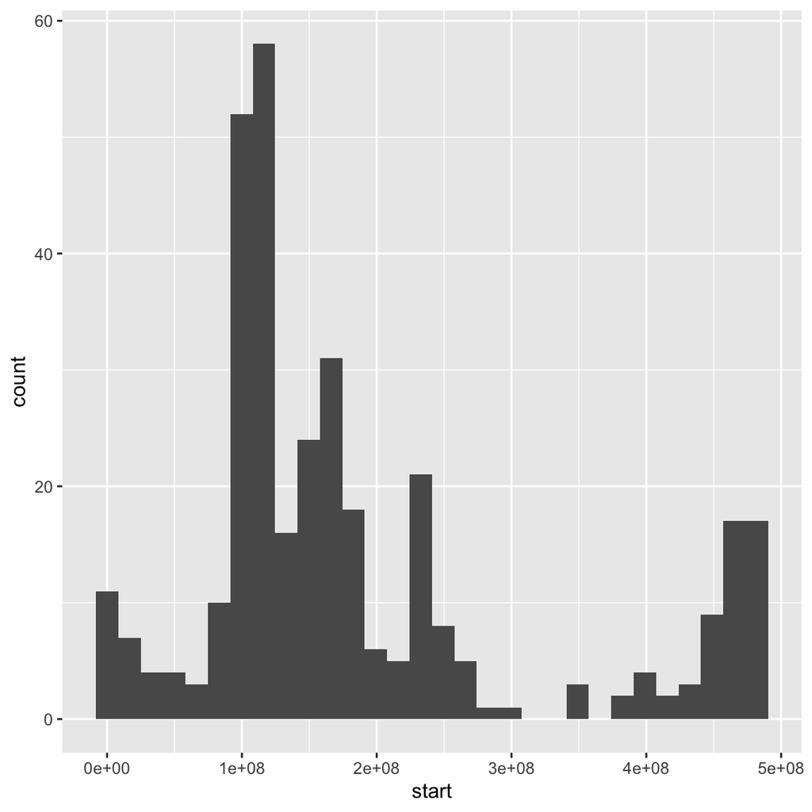

```r
# similar dist
##plot lost genes dist
yloss_filt<-filter(yloss_blast,chr == "X" ) %>%  filter(!grepl("\\|",hap1))
ggplot(data = yloss_filt,aes(start)) +geom_histogram()
```

```r
## spike around 100-200 Mb
```

#### gene loss - which files

Distributions don’t look hugely different. will continue one w the set with sal orthos to keep consistent w the analyses above - because otherwise we might mix in genes there w ortho between hap1 and hap2 2 but not sal

```r
mylist<-yloss_filt %>% select(hap1) %>%
  add_column(status = "lost")
mydf<- xtotal %>%
    left_join(mylist, by = c('hap1')) %>%
  mutate(start_mb = start/1e6)
```

#### plotting gene loss along X

```r
# Assuming your DataFrame is named 'df'
library(zoo)
mydf<-slr_rename_h1(mydf)
# Sort the DataFrame by the 'start' column
#df <- df[order(df$start), ]

# Create a rolling window of 20 observations with a step size of 1
#rolling_window <- rollapply(df$status, by.column = FALSE,width = 20, FUN = function(x) sum(!is.na(x)), align = "right", fill = NA)
```

Rolling window functions with mutate

```r
rolling_window_fun<- function(values,win){rollapply(values,by.column=FALSE,width=win,FUN = function(x) (sum(!is.na(x))/win),
                                                                   align="right",fill=NA)
  }
# Add the rolling window result as a new column in the DataFrame
#df$sliding_window_count <- rolling_window

# Display the updated DataFrame
#print(df)
#ggplot(data = df,aes(start,sliding_window_count)) +geom_line()


#ggplot(data = df,aes(start,sliding_window_count)) +geom_line()
#rolling_window <- rollapply(df$status, by.column = FALSE,width = 20, FUN = function(x) (sum(!is.na(x))/20), align = "right", fill = NA)
#df$sliding_window_propn <- rolling_window

df1<- mydf %>%
  #arrange(start) %>%
  mutate(roll_prop = rolling_window_fun(status,20))

# ggplot(data = df,aes(start,sliding_window_propn)) +
#   geom_line() +
#   ylab("Proportion of genes lost on Y per window") +
#   xlab("Position on X (Mb)") +
#   theme_cowplot()
# plots are same
unique(df1$region)
```

```
## [1] "PAR1" "OldX" "NewX" "PAR2"
```

```r
library(RColorBrewer)
mypal<-brewer.pal(4,"Dark2")[c(2,1,4,4)] # needs to match prev plot

xplot<-ggplot(data = df1,aes(start_mb,roll_prop)) +
  geom_line(aes(color = region)) +
  ylab("Proportion of genes\n lost on Y per window") +
  xlab("Position on X (Mb)") +
  theme_cowplot() +
  scale_color_manual(values = mypal) +
  theme(legend.position = "none")

## to do: add to previous geneloss plot
```

#### create complete figure of X gene loss

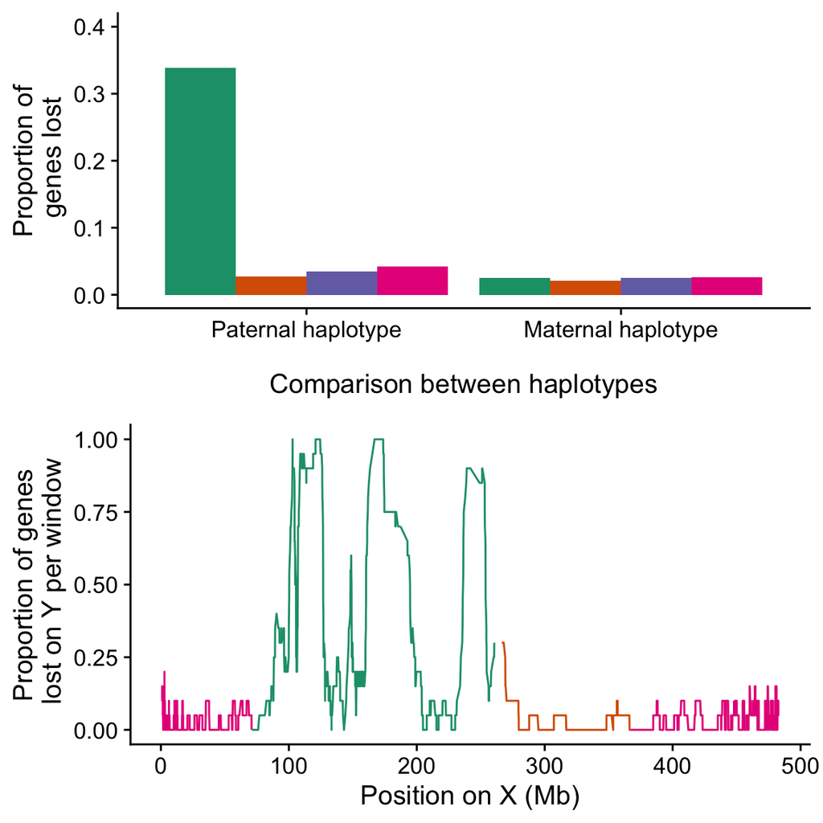

```r
plot_grid(bothlossplot,xplot,ncol=1)
```

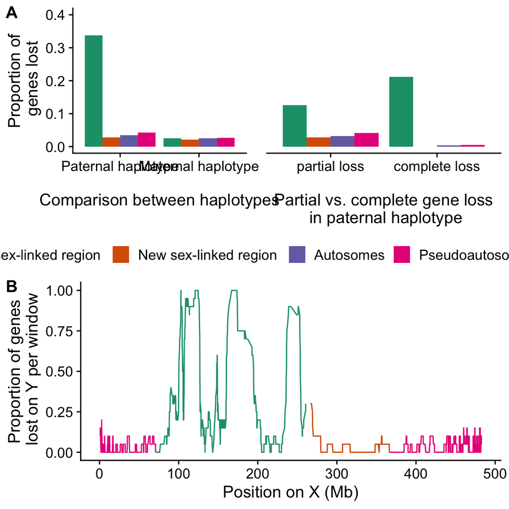

```r
plot_grid(upper_row,
         bottom_row, xplot,
        labels = c('A','','B'),
        ncol = 1, rel_heights = c(6,1,6))
```

```r
#ggsave("multipaneltest.pdf",height =8, width = 10)
```

#### geneloss along positions relative to salicifolius

Adding positions and chromosome info for salicifolius

```r
salkey<-readr::read_delim("input_to_output.txt",col_names =c("old","new"),show_col_types = FALSE)
salkey<-salkey %>% mutate(fix=str_replace(old, "\\=", "\\_")) %>%
  mutate(.,fix=str_replace(fix, "\\;", "\\_")) %>% select(fix,new)
salkey<-as.data.frame(salkey)

salclean<-sal_raw %>% filter(genome == "salicifolius") %>%select(repGene,chr,start,end) %>%
  rename(salicifolius =repGene,salchr = chr, salstart=start, salend=end) %>%
  dplyr::mutate(salChr = case_when(salchr == salkey[1,1] ~ salkey[1,2],
                        salchr == salkey[2,1] ~ salkey[2,2],
                        salchr == salkey[3,1] ~ salkey[3,2],
                        salchr == salkey[4,1] ~ salkey[4,2],
                        salchr == salkey[5,1] ~ salkey[5,2],
                        salchr == salkey[6,1] ~ salkey[6,2],
                        salchr == salkey[7,1] ~ salkey[7,2],
                        salchr == salkey[8,1] ~ salkey[8,2],
                        salchr == salkey[9,1] ~ salkey[9,2],
                        salchr == salkey[10,1] ~ salkey[10,2]))
head(salclean)
```

```
##               salicifolius             salchr salstart salend      salChr
## 1: R_salicifolius_00006022 ScaOOZI_1_HRSCAF_1    13914  18971 Scaffold_10
## 2: R_salicifolius_00006023 ScaOOZI_1_HRSCAF_1    30034  31225 Scaffold_10
## 3: R_salicifolius_00006024 ScaOOZI_1_HRSCAF_1    31705  36095 Scaffold_10
## 4: R_salicifolius_00006026 ScaOOZI_1_HRSCAF_1   119314 122040 Scaffold_10
## 5: R_salicifolius_00006027 ScaOOZI_1_HRSCAF_1   204772 206765 Scaffold_10
## 6: R_salicifolius_00006028 ScaOOZI_1_HRSCAF_1   209172 213159 Scaffold_10
```

```r
df2<-left_join(df1,salclean)%>% drop_na(.,salChr) %>% select(.,-roll_prop) %>% mutate(salstart_mb=salstart/1e6)
#df2
#df2 <- df2[order(df2$salstart), ]
#df2
#rolling_window <- rollapply(df2$status, by.column = FALSE,width = 20, FUN = function(x) (sum(!is.na(x))/20), align = "right", fill = NA)
```

```r
df3<-df2 %>%
  group_by(salchr) %>%
  arrange(salstart_mb,.by_group=TRUE) %>%
  mutate(roll_prop = rolling_window_fun(status,20))
```

```r
#rolling_window_fun(df2,20)
#rolling_window
#df2$sliding_window_propn <- rolling_window
head(df3)
```

```
## # A tibble: 6 × 21
## # Groups:   salchr [1]
##    pgID interpChr interpOrd    og repGene       genome chr    start    end hap1
##   <int> <chr>         <dbl> <int> <chr>         <chr>  <chr>  <int>  <int> <chr>
## 1 11339 X              8315 15902 NChap1_final… hap1   X     3.98e8 3.98e8 NCha…
## 2 11337 X              8314 15900 NChap1_final… hap1   X     3.98e8 3.98e8 NCha…
## 3 11334 X              8312 15903 NChap1_final… hap1   X     3.98e8 3.98e8 NCha…
## 4 11325 X              8308 15950 NChap1_final… hap1   X     3.97e8 3.97e8 NCha…
## 5 11398 X              8359 15984 NChap1_final… hap1   X     3.99e8 3.99e8 NCha…
## 6 11385 X              8347 15965 NChap1_final… hap1   X     3.98e8 3.98e8 NCha…
## # ℹ 11 more variables: salicifolius <chr>, hap2 <chr>, status <chr>,
## #   start_mb <dbl>, region <chr>, salchr <chr>, salstart <int>, salend <int>,
## #   salChr <chr>, salstart_mb <dbl>, roll_prop <dbl>
```

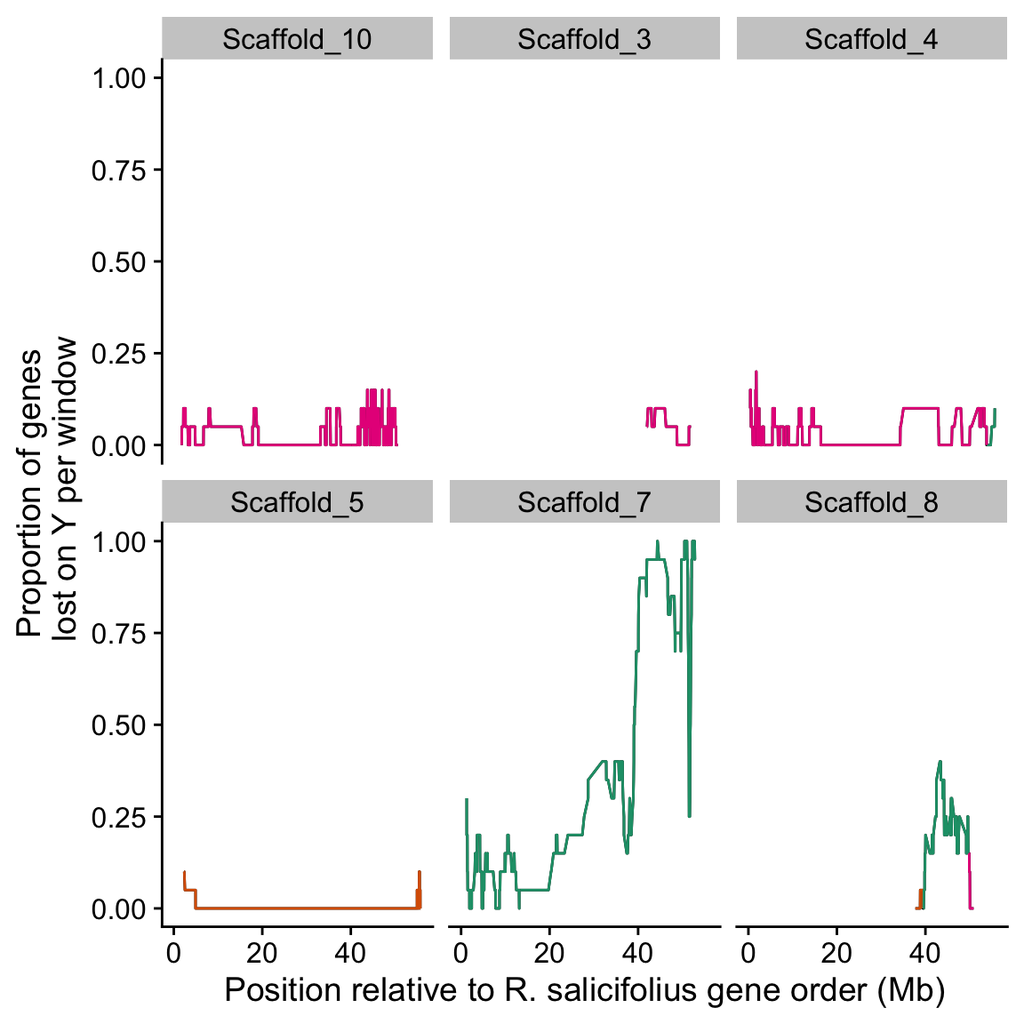

```r
## scaffold_6 has all NAs - face_wrap leaves it in, need to filter out.
salplot<-ggplot(data = filter(df3,salChr!="Scaffold_6"),aes(salstart_mb,roll_prop)) +
  geom_line() +
  geom_line(aes(color = region)) +
  ylab("Proportion of genes\n lost on Y per window") +
  xlab("Position relative to R. salicifolius gene order (Mb)") +
  theme_cowplot() +
  scale_color_manual(values = mypal) +
   theme(legend.position = "none")+
  facet_wrap(~salChr,drop = TRUE)
salplot
```

```r
ggsave("sal_position_geneloss.pdf",height = 6, width = 8)
```

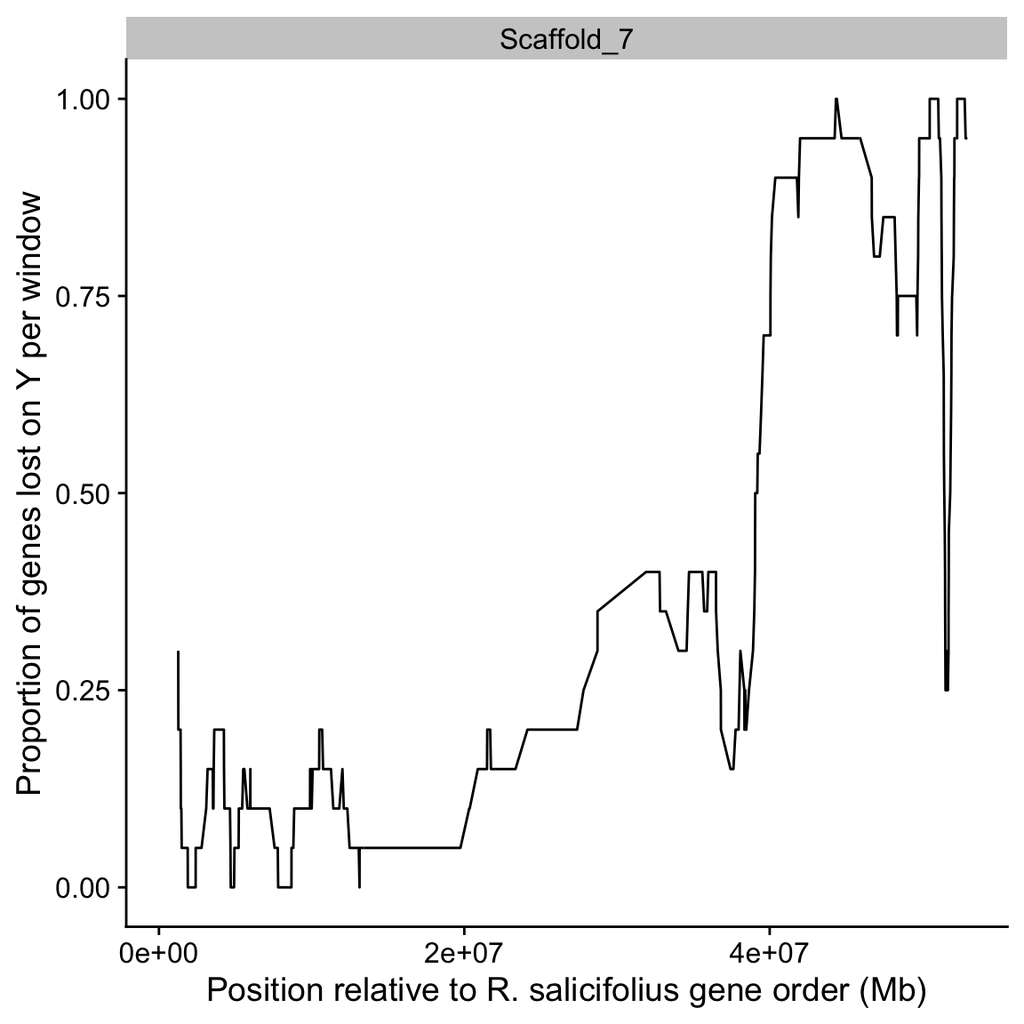

```r
ggplot(data = filter(df3,salChr == "Scaffold_7"),aes(salstart,roll_prop)) +
  geom_line() +
  facet_wrap(~salChr) +
  ylab("Proportion of genes lost on Y per window") +
  xlab("Position relative to R. salicifolius gene order (Mb)") +
  theme_cowplot()
```

```r
ggsave("sal_scaf7_ygeneloss.pdf",height = 6, width = 8)
filter(df3,salchr == "scaffold_7")
```

```
## # A tibble: 0 × 21
## # Groups:   salchr [0]
## # ℹ 21 variables: pgID <int>, interpChr <chr>, interpOrd <dbl>, og <int>,
## #   repGene <chr>, genome <chr>, chr <chr>, start <int>, end <int>, hap1 <chr>,
## #   salicifolius <chr>, hap2 <chr>, status <chr>, start_mb <dbl>, region <chr>,
## #   salchr <chr>, salstart <int>, salend <int>, salChr <chr>,
## #   salstart_mb <dbl>, roll_prop <dbl>
```

```r
# plot all
```

Plot everything

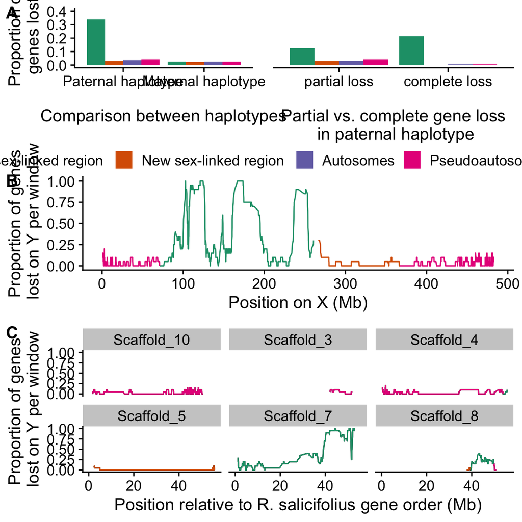

```r
plot_grid(upper_row,
         bottom_row, xplot,salplot,
        labels = c('A','','B','C'),
        ncol = 1, rel_heights = c(9,1,9,12))
```

```r
ggsave("multipanel_geneloss_sept11.pdf",height =10, width = 12)
```